# 07_Best_Model

## 6. Mejor modelo e hiperparámetros

### Librerías

```python
from sklearn.ensemble import RandomForestClassifier
from sklearn.metrics import classification_report
from funciones_metricas import *
from sklearn.model_selection import RandomizedSearchCV
from sklearn.metrics import make_scorer
from sklearn.metrics import confusion_matrix
from scipy.stats import randint

import matplotlib.pyplot as plt
import numpy as np
import pandas as pd
import seaborn as sns
import scikitplot as skp

import warnings
warnings.filterwarnings('ignore')
```

### Carga de datos

```python
path_folder = "./"
x_train_0 = pd.read_csv(path_folder +"Xtrain0_data.csv", low_memory=False)
x_train_1 = pd.read_csv(path_folder +"Xtrain1_data.csv", low_memory=False)
x_val = pd.read_csv(path_folder +"Xval_data.csv", low_memory=False)
x_test = pd.read_csv(path_folder +"Xtest_data.csv", low_memory=False)

y_train_0 = pd.read_csv(path_folder +"ytrain0_data.csv", low_memory=False)
y_train_1 = pd.read_csv(path_folder +"ytrain1_data.csv", low_memory=False)
y_val = pd.read_csv(path_folder +"yval_data.csv", low_memory=False)
y_test = pd.read_csv(path_folder +"ytest_data.csv", low_memory=False)
```

## 1. Modelo seleccionado: Random Forest

#### Inspección de datos

```python
x_train = x_train_0
y_train = y_train_0
```

#### Modelado

```python
# Entrenamiento
modelo_randomforest = RandomForestClassifier(n_estimators=10, random_state=42)
modelo_randomforest = modelo_randomforest.fit(x_train, y_train)
modelo_randomforest
```

```
RandomForestClassifier(n_estimators=10, random_state=42)
```

```python
# Predicción
y_pred = modelo_randomforest.predict(x_train)
y_pred
```

```
array([0, 0, 0, ..., 1, 1, 1], dtype=int64)
```

#### Evaluación del modelo

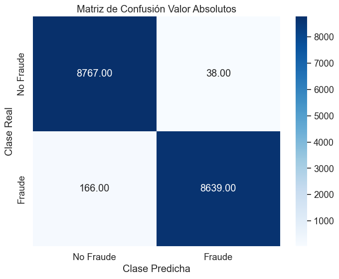

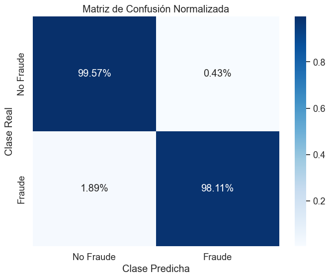

```python
plot_confusion_matrices(y_train, y_pred)
```

```
Best Threshold=1.000, F1-Score=0.988
```

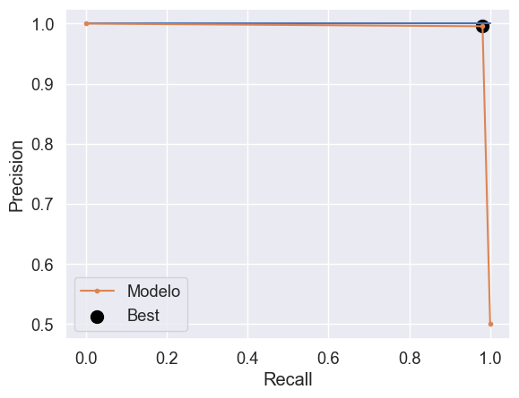

```
F-Score: 0.98833
```

```python
custom_metrics = evaluar_modelo_precision_recall(y_train, y_pred)
```

## 7. Optimización de hiperparámetros con validación cruzada en el modelo Random Forest

· Los hiperparámetros son configuraciones externas al modelo de aprendizaje automático que afectan su rendimiento pero que no son aprendidos automáticamente durante el entrenamiento. A diferencia de los parámetros del modelo, que son aprendidos a partir de los datos durante el proceso de entrenamiento, los hiperparámetros deben ser establecidos antes de entrenar el modelo y no cambian durante el proceso de entrenamiento.

· Los hiperparámetros son esenciales para optimizar el rendimiento de un modelo y ajustarlo mejor a un conjunto de datos específico.

· El proceso de ajustar y seleccionar los hiperparámetros óptimos se conoce como "optimización de hiperparámetros". Se ha empleado el método de búsqueda aleatoria (`Random Search`) para mejorar la eficiencia del modelo, ya que a través de la búsqueda en cuadrícula (`Grid Search`) resultaba un trabajo más exhaustivo y minucioso.

```python
# Hiperparámetros
param_dist = {
    'n_estimators': [50, 100, 200],
    'max_depth': [None, 10, 20],
    'min_samples_split': [2, 5, 10],
    'min_samples_leaf': [1, 2, 4]
}
```

**Descripción de los hiperparámetros** · En un modelo de Random Forest, los parámetros especificados en el `param_grid` son hiperparámetros que se pueden ajustar para optimizar el rendimiento del modelo. Aquí está la interpretación de estos parámetros:

1. **`n_estimators`:**
   - Se trata del número de árboles en el bosque. En este caso se están probando tres valores: 50, 100 y 200 árboles. Cuánto mayor sea el número de árboles, más robusto y generalizado puede ser el modelo, pero esto también puede hacer que aumente el coste computacional.
2. **`max_depth`:**
   - Describe la profundidad máxima de cada árbol en el bosque. Se emplean tres valores: 'none', sin límite de profundidad, 10 y 20. De esta forma, se controla la complejidad de cada árbol y, por lo tanto, el nivel de sobreajuste, en este caso, que se podría haber producido al obtener unas buenas métricas durante el entrenamiento del modelo.
3. **`min_samples_split`:**
   - Este hiperparámetro enseña el número mínimo de muestras requeridas para dividir un nodo interno. Se prueban tres valores: 2, 5 y 10. Cuanto mayor sea este valor, más probable es que los árboles tengan nodos más grandes y, por lo tanto, una mayor capacidad para sobreajustar.
4. **`min_samples_leaf`:**
   - El número mínimo de muestras requeridas para estar en un nodo hoja, probando con valores 1, 2 y 4. Controla la cantidad mínima de muestras en una hoja, lo que puede influir en la suavidad del modelo.

Al realizar una búsqueda aleatoria con estos conjuntos de valores, se está explorando el espacio de hiperparámetros de manera más eficiente en comparación con una búsqueda de cuadrícula (grid search), que probaría todas las combinaciones posibles. Esto es especialmente útil, puesto que el espacio de búsqueda de datos puede llevar un coste de recursos computacionales elevados y que no resultan ilimitados.

### Selección de métrica

La métrica empleada para valorar el rendimiento y la eficiencia del modelo Random Forest en su predicción es la matriz de confusión así como la sensibilidad y la precisión.

```python
custom_metrics(y_train, y_pred)
```

```
0.8815786484951731
```

```python
scorer = make_scorer(custom_metrics)
```

Con la configuración de los hiperparámetros y la posterior aplicación de la métrica se puede apreciar cómo se ha reducido los resultados en comparación a entrenamientos previos.

### Aplicación del Random Search con validación cruzada

```python
random_search = RandomizedSearchCV(
    modelo_randomforest,   # Modelo de Random Forest
    param_distributions=param_dist,  # Diccionario con los hiperparámetros y las distribuciones para muestrear
    n_iter=10,  # Número de combinaciones aleatorias a probar
    cv=5,  # Número de divisiones para la validación cruzada
    scoring=scorer,  # Métrica de evaluación a utilizar
    random_state=42  # Semilla para reproducibilidad de los resultados
)
```

1. **`modelo_randomforest`:** es el modelo de Random Forest empleado como estimador y definido previamente.
2. **`param_distributions`:** es un diccionario que define el espacio de búsqueda de hiperparámetros. De esta forma, para cada hiperparámetro, proporcionas una distribución desde la cual se muestrearán los valores durante la búsqueda aleatoria. Este diccionario contiene los hiperparámetros mencionados previamente: (`n_estimators`, `max_depth`, `min_samples_split`, `min_samples_leaf`) con las distribuciones asociadas.
3. **`n_iter`:** es el número de combinaciones aleatorias de hiperparámetros que se probarán. En este caso, se están probando 10 combinaciones aleatorias.
4. **`cv`:** es el número de divisiones para la validación cruzada. En este caso, se utiliza validación cruzada estratificada con 5 divisiones (`cv=5`), lo que significa que el conjunto de datos se divide en 5 partes, y el modelo se entrena y evalúa 5 veces, utilizando cada parte como conjunto de prueba en una iteración diferente.
5. **`scoring`:** especifica la métrica de evaluación que se utiliza para evaluar la calidad de las combinaciones de hiperparámetros. En este caso se hace uso de 'custom_metrics', que parten de la sensibilidad y precisión así como de los resultados obtenidos en la matriz de confusión.
6. **`random_state`:** es la semilla utilizada por el generador de números aleatorios, y que, de esta forma, los resultados sean reproducibles.

```python
# Entrenamiento
random_search.fit(x_train, y_train)
```

```
RandomizedSearchCV(cv=5,
                   estimator=RandomForestClassifier(n_estimators=10,
                                                    random_state=42),
                   param_distributions={'max_depth': [None, 10, 20],
                                        'min_samples_leaf': [1, 2, 4],
                                        'min_samples_split': [2, 5, 10],
                                        'n_estimators': [50, 100, 200]},
                   random_state=42, scoring=make_scorer(custom_metrics))
```

```python
# Obtener los mejores hiperparámetros
mejores_hiperparametros = random_search.best_params_
```

### Resultados

```python
print("Mejores hiperparámetros encontrados:")
print(random_search.best_params_)
print("Mejor puntuación encontrada:")
print(random_search.best_score_)
```

```
Mejores hiperparámetros encontrados:
{'n_estimators': 100, 'min_samples_split': 10, 'min_samples_leaf': 2, 'max_depth': 20}
Mejor puntuación encontrada:
0.6972174900624646
```

Estos sería los mejores hiperparámetros detectados con Random Search y validación cruzada, obteniendo la mejor puntuación con un 0.69:

1. 'n_estimators': 100
2. 'min_samples_split': 10
3. 'min_samples_leaf': 2
4. 'max_depth': 20